# Project: Investigate a Dataset - No Show Appointments

## Plotting the charts of each of the features to determine which affects the appearance of patients at their appointments

```python
def PlotFunction(dfr, colname, color):

    counts = dfr.groupby(['No_show']).mean()[colname]
    counts.plot(kind ='bar',title='Appearance by '+colname, color= color, alpha=0.7)
    plt.xlabel(colname, fontsize=18)
    plt.ylabel('Count', fontsize=18);
```

#### Note that No means that patients appeared for their appointments while Yes means that patients did not show up for their appointments!

## Age

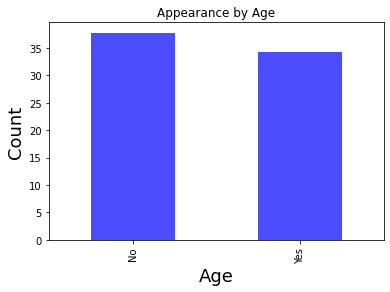

```python
PlotFunction(df, 'Age', 'blue')
```

From the above chart, more older patients showed up for their appointments

## Scholarship

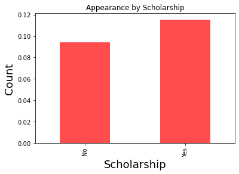

```python
PlotFunction(df, 'Scholarship', 'red')
```

```python
df.query('No_show == "Yes"')['Handcap'].count(), df.query('No_show == "No"')['Handcap'].count()
```

```
(22319, 88208)
```

## Handcap

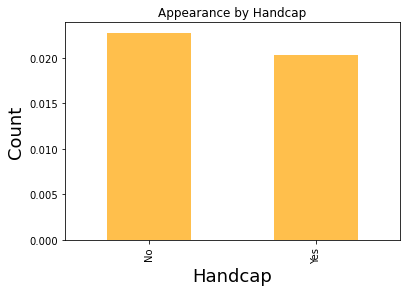

```python
PlotFunction(df, 'Handcap', 'orange')
```

From the above, more handicap patients made their appointments

## Diabetes

[figure not shown]

```python
PlotFunction(df, 'Diabetes', '')
```

From, the above, more diabetic patients appeared for their appointments

## Hypertension

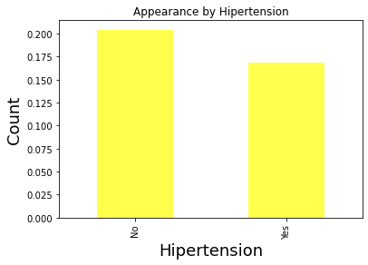

```python
PlotFunction(df, 'Hipertension', 'yellow')
```

More hypertensive patients also made their appointments according to the above chart

## Alcoholism

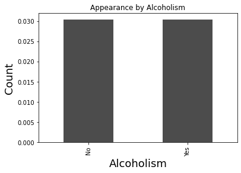

```python
PlotFunction(df, 'Alcoholism', 'black')
```

The chart above shows that same number of alcoholic patients who did not show up showed up, hence Alcoholism is not a determining factor for patients showing up for their appointments

## Received SMS

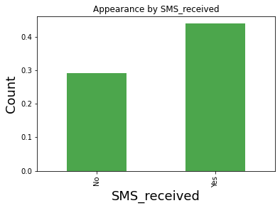

```python
PlotFunction(df, 'SMS_received', 'green')
```

### Figures below show the distribution of patients that didn't show up and those that showed up for their appointments.

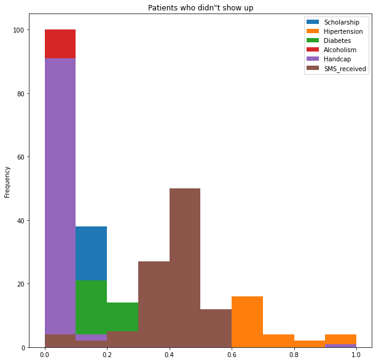

```python
noshow.groupby(['Age']).mean().plot(kind='hist', figsize=(10,10), title='Patients who didn"t show up')
plt.legend();
```

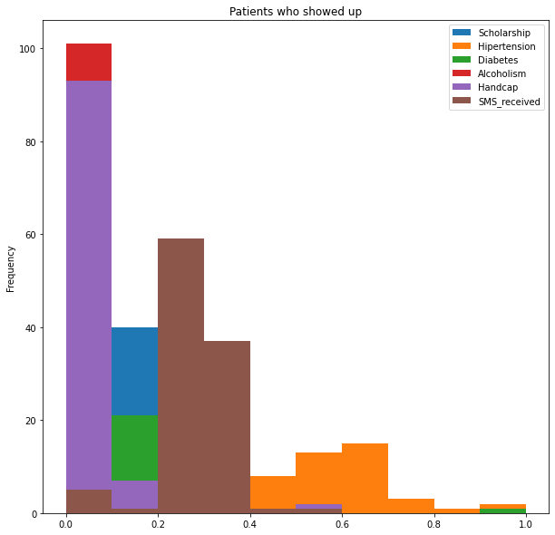

```python
show.groupby(['Age']).mean().plot(kind='hist', figsize=(10,10), title='Patients who showed up')
plt.legend();
```

## Conclusions

### What factors are important for us to know in order to predict if a patient will show up for their scheduled appointment?

Factors include:

1. Age
2. Type of disease excluding Alcoholism

### Limitations

- One major limitation to the analysis is the fact that not enough features or factors are considered in determining whether patients in Brazil will show up for their appointments. For example, factors like location could not be considered as the data did not capture all parts of Brazil. Furthermore, all the diseases mentioned in the data do not include every illness that may be common to the populace of Brazil. In all, this data is not robust enough to determine whether or not the patients of Brazil will show up for their hospital/doctor's appointments.

## Submitting your Project

> **Tip**: Before you submit your project, you need to create a .html or .pdf version of this notebook in the workspace here. To do that, run the code cell below. If it worked correctly, you should get a return code of 0, and you should see the generated .html file in the workspace directory (click on the orange Jupyter icon in the upper left).

> **Tip**: Alternatively, you can download this report as .html via the **File** > **Download as** submenu, and then manually upload it into the workspace directory by clicking on the orange Jupyter icon in the upper left, then using the Upload button.

> **Tip**: Once you've done this, you can submit your project by clicking on the "Submit Project" button in the lower right here. This will create and submit a zip file with this .ipynb doc and the .html or .pdf version you created. Congratulations!

```python
from subprocess import call
call(['python', '-m', 'nbconvert', 'Investigate_a_Dataset.ipynb'])
```

```
1
```